# Concessão de Crédito

Aprendizado de Máquina - Modelo de Regressão

# 1 Objetivos

- Construir Modelo Preditivo que seja capaz de prever a quantidade de um determinado valor a ser emprestado ao cliente dado que ele tem boas chances de ser um bom pagador.
- Quais Modelos utilizar ?
- Modelos no Radar
  - Modelos Lineares Generalizados
  - Modelos de Machine Learning
- Métricas de Performance
- - RMSE

# 2 Conjunto de dados

```r
df <- fread('../outputs/df_abt.csv',
                     sep=",",
                     showProgress = FALSE)[,-1] %>%
                     data.frame(stringsAsFactors = T)
```

```r
head(df)
```

|  | Loan_ID | Gender | Married | Dependents | Education | Self_Employed | ApplicantIncome | CoapplicantIncome | LoanAmount | Loan_Amount_Term | Credit_History | Property_Area | Loan_Status |
| --- | --- | --- | --- | --- | --- | --- | --- | --- | --- | --- | --- | --- | --- |
| 1 | LP001002 | Male | No | 0 | Graduate | No | 5849 | 0 | 153.6016 | 360 | 1 | Urban | Y |
| 2 | LP001003 | Male | Yes | 1 | Graduate | No | 4583 | 1508 | 128.0000 | 360 | 1 | Rural | N |
| 3 | LP001005 | Male | Yes | 0 | Graduate | Yes | 3000 | 0 | 66.0000 | 360 | 1 | Urban | Y |
| 4 | LP001006 | Male | Yes | 0 | Not Graduate | No | 2583 | 2358 | 120.0000 | 360 | 1 | Urban | Y |
| 5 | LP001008 | Male | No | 0 | Graduate | No | 6000 | 0 | 141.0000 | 360 | 1 | Urban | Y |
| 6 | LP001011 | Male | Yes | 2 | Graduate | Yes | 5417 | 4196 | 267.0000 | 360 | 1 | Urban | Y |

# 3 Ajustando um modelo aos dados

Como a distribuição da variável LoanAmount é assimétrica com cauda a direita, podemos utilizar um MLG, modelos linerares generalizados, em particular a distribuição Gamma.

Ainda é importante lembrar que dentro do contexto de negócio o processo de seleção de variáveis conta com o apoio dos especialistas da área, o que ajuda bastante, porém as vezes por questões intrínsecas do negócio uma variável que é rejeitada por algum método de seleção acaba permanecendo no modelo.

## 3.1 Split no conjunto de dados

```r
set.seed(42)
index <- createDataPartition(df$LoanAmount, p = 0.7, list = FALSE)

df.train <- df[index, ]
df.test  <- df[-index,]
```

[output not shown]

# 4 Matrix de Correlação

```r
cor(df[,unlist(lapply(df,class)=='numeric')])
```

```
##                   ApplicantIncome CoapplicantIncome LoanAmount Loan_Amount_Term
## ApplicantIncome        1.00000000       -0.11660458 0.57817514      -0.04530112
## CoapplicantIncome     -0.11660458        1.00000000 0.18302107      -0.06010426
## LoanAmount             0.57817514        0.18302107 1.00000000       0.03822045
## Loan_Amount_Term      -0.04530112       -0.06010426 0.03822045       1.00000000
```

```r
set.seed(548)
fit.model = glm(LoanAmount ~ Married + Education + ApplicantIncome +
                             CoapplicantIncome + Loan_Amount_Term +
                             Property_Area + Loan_Status,
                             data = df.train[,-1],family = Gamma(link = "log"))

summary(fit.model)
```

```
##
## Call:
## glm(formula = LoanAmount ~ Married + Education + ApplicantIncome +
##     CoapplicantIncome + Loan_Amount_Term + Property_Area + Loan_Status,
##     family = Gamma(link = "log"), data = df.train[, -1])
##
## Deviance Residuals:
##     Min       1Q   Median       3Q      Max
## -2.0368  -0.2041  -0.0154   0.1498   0.9895
##
## Coefficients:
##                          Estimate Std. Error t value Pr(>|t|)
## (Intercept)             4.162e+00  1.147e-01  36.291  < 2e-16 ***
## Marriedvnd              3.552e-01  1.986e-01   1.788  0.07441 .
## MarriedYes              9.828e-02  3.508e-02   2.802  0.00532 **
## EducationNot Graduate  -7.349e-02  4.066e-02  -1.807  0.07141 .
## ApplicantIncome         5.224e-05  2.858e-06  18.276  < 2e-16 ***
## CoapplicantIncome       6.790e-05  6.015e-06  11.288  < 2e-16 ***
## Loan_Amount_Term        1.168e-03  2.792e-04   4.183  3.5e-05 ***
## Property_AreaSemiurban -1.341e-02  4.092e-02  -0.328  0.74330
## Property_AreaUrban     -1.029e-01  4.215e-02  -2.441  0.01505 *
## Loan_StatusY           -5.182e-02  3.658e-02  -1.416  0.15740
## ---
## Signif. codes:  0 '***' 0.001 '**' 0.01 '*' 0.05 '.' 0.1 ' ' 1
##
## (Dispersion parameter for Gamma family taken to be 0.1149113)
##
##     Null deviance: 107.068  on 431  degrees of freedom
## Residual deviance:  59.318  on 422  degrees of freedom
## AIC: 4591.2
##
## Number of Fisher Scoring iterations: 12
```

## 4.1 Teste Qui-Quadrado

```r
round(1-pchisq(59.318,422, ncp = 0, lower.tail = T, log.p = F),4)
```

```
## [1] 1
```

O desvio do modelo foi de D($y$;$\hat{\mu}$) = 59.318, com 422 graus de liberdade, que leva a P = 1,00 e indica um ajuste adequado.

## 4.2 Predição

```r
predicao <- exp(predict(fit.model,df.test))
```

## 4.3 Plot Ecdf

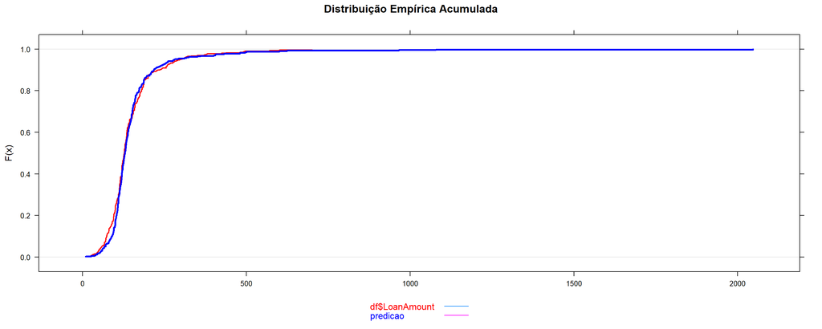

```r
latticeExtra::ecdfplot(~ df$LoanAmount + predicao,
                         auto.key=list(space='bottom',col = c('red','blue')),
                         col = c('red','blue'),
                         lwd = c(2,3),
                         xlab =" ",ylab = 'F(x)',
                         main = 'Distribuição Empírica Acumulada')
```

Observe que há concordância entre os valores preditos e reais da variável **LoanAmount**. Uma outra forma de verificar essa condordância é plotar as distribuições de densidade e frequência, como fiz abaixo.

```r
predicao <- data.frame('predicao' = predicao)
```

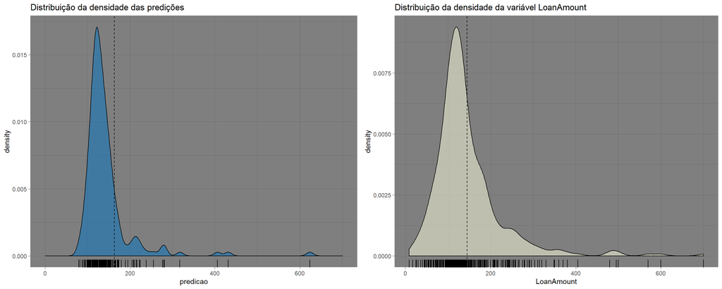

```r
p1 <- ggpubr::ggdensity(predicao, x = "predicao",
              fill = "#0073C2FF", color = "black",
              add = "mean", rug = TRUE) +
              xlim(xlim = c(0,700)) +
              #ylim(ylim = c(0,0.02)) +
              labs(title = 'Distribuição da densidade das predições') +
              theme_dark()

p2 <- ggpubr::ggdensity(fit.model$data, x = "LoanAmount",
              fill = "lightyellow", color = "black",
              add = "mean", rug = TRUE) +
              #ylim(ylim = c(0,0.015)) + #xscale("log2", .format = TRUE)
              labs(title = 'Distribuição da densidade da variável LoanAmount') +
              theme_dark()

gridExtra::grid.arrange(p1,p2,nrow = 1)
```

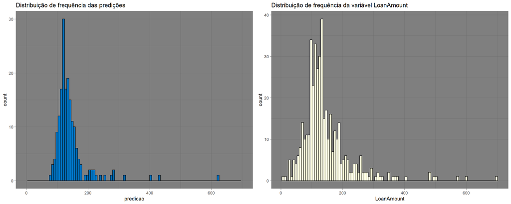

```r
p3 <- ggplot(predicao, aes(x = predicao)) +
      geom_histogram(bins = 100,
                     color = "black",
                     fill = "#0073C2FF") +
      xlim(xlim = c(0,700) ) +
#      ylim(ylim = c(0,100)) +
      labs(title = 'Distribuição de frequência das predições') +
      theme_dark()

p4 <- ggplot(fit.model$data, aes(x = LoanAmount)) +
      geom_histogram(bins = 100,
                     color = "black",
                     fill = "lightyellow") +
 #     xlim(xlim = c(0,max(fit.model$LoanAmount))) +
 #     ylim(ylim = c(0,100)) +
      labs(title = 'Distribuição de frequência da variável LoanAmount') +
      theme_dark()


gridExtra::grid.arrange(p3,p4,nrow = 1)
```

Observe que de certa forma o conseguimos estimar o comportamento da distribuição da variável LoanAmount.

# 5 Métricas de Performance

## 5.1 Rsquare

```r
rss <- sum((fit.model$residuals)^2)  ## soma dos quadrados dos resíduos
tss <- sum((fit.model$y - mean(fit.model$y))^2)  ## soma total dos quadrados
(r.square <- 1-rss/tss)
```

```
## [1] 0.9999828
```

Este é um bom resultado para uma primeira iteração, o modelo consegue explicar cerca de 99% da variabilidade dos dados.

## 5.2 RMSE

```r
sqrt(mean((fit.model$residuals)^2))
```

```
## [1] 0.3350392
```

Com esse RMSE somente o kaggle me dirá se está bom ou não.

# 6 Diagnósticos

```r
car::Anova(fit.model)
```

|  | LR Chisq | Df | Pr(>Chisq) |
| --- | --- | --- | --- |
| Married | 9.935056 | 2 | 6.960332e-03 |
| Education | 3.121752 | 1 | 7.725367e-02 |
| ApplicantIncome | 271.553719 | 1 | 5.203393e-61 |
| CoapplicantIncome | 121.531914 | 1 | 2.922620e-28 |
| Loan_Amount_Term | 15.965405 | 1 | 6.451065e-05 |
| Property_Area | 7.328118 | 2 | 2.562827e-02 |
| Loan_Status | 2.035018 | 1 | 1.537124e-01 |

## 6.1 Do Modelo

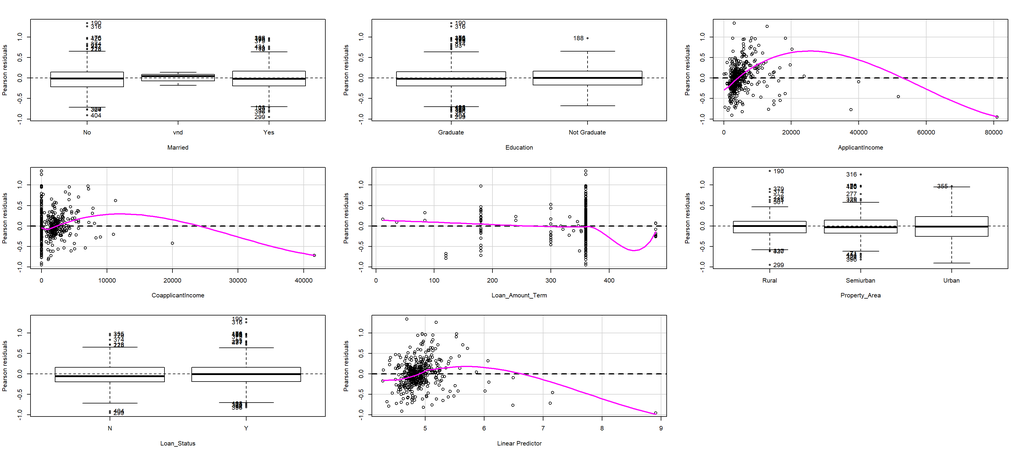

```
##                   Test stat Pr(>|Test stat|)
## Married
## Education
## ApplicantIncome      8.9910         0.002713 **
## CoapplicantIncome    2.0384         0.153368
## Loan_Amount_Term     0.0901         0.764027
## Property_Area
## Loan_Status
## ---
## Signif. codes:  0 '***' 0.001 '**' 0.01 '*' 0.05 '.' 0.1 ' ' 1
```

```r
car::residualPlots(fit.model)
```

## 6.2 Resíduos

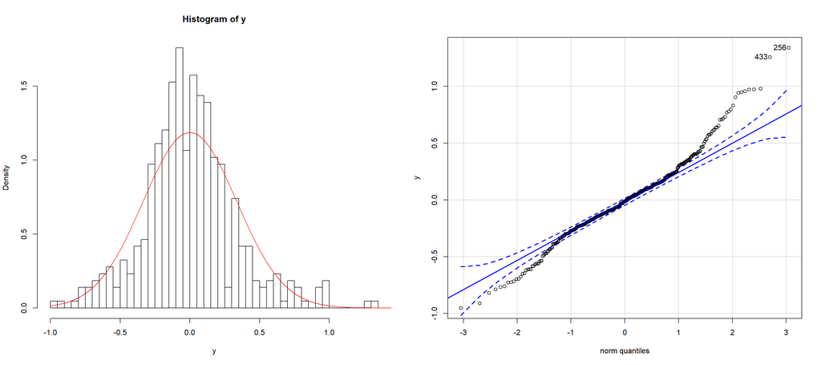

```
## 256 433
## 190 316
```

```r
par(mfrow=c(1,2))
y = fit.model$residuals
mean.y <- mean(y)
sd.y <- sd(y)
hist(y, probability=T, breaks = 60)
y.range <- seq(floor(min(y)), ceiling(max(y)), 0.05)
x <- dnorm(y.range, mean=mean.y, sd=sd.y)
lines(y.range, x, col="red")
car::qqPlot(y)
```

# 7 Conclusão

Como os resíduos estão bem distribuídos em torno de zero podemos considerar que nosso ajuste está razoável para uma primeira iteração de análises. Além disso é interessante notar que os resíduos que estão muito acima de zero podem ser os casos em que o valor do empréstimo concedido ao cliente está acima da sua capacidade de pagamento o que implicando em um aumento do risco de retorno dos valores, logo, da inadimplência.

Já os valores dos resíduos que estão abaixo de zero significa que o valor concedido ao cliente está dentro das suas possibilidades de pagamento da dívida adiquirida, o que necessariamento reduz o risco de inadimplência.

## 7.1 Exportando o Modelo

```r
saveRDS(fit.model,'../outputs/regression_model.rds')
```

Sérgio Carvalho

30 novembro, 2019